# Visual detection of cryptic displays in jumping spiders - Supplementary Material 5

## Massimo De Agrò (1), Francesca Lo Bello (1), Peter Neri (2, 3), Giorgio Vallortigara (1)

#### 1 - Braitenberg Brain Research Hub, Department of Psychology and Cognitive sciences, University of Trento, Italy

#### 2 - Italian Institute of Technology, Genoa, Italy

#### 3 - Laboratoire des Systèmes Perceptifs (UMR8248), École normale supérieure, PSL Research University, Paris, France

#### Corresponding Author: Massimo De Agrò massimo.deagro@unitn.it

In the main analysis we used the binary reaction of spiders to stimuli presentation: either the animal performed a pivot or not. When selecting the binary outcomes from the treadmill data, we also collected secondary variables, namely the rotation magnitude (how many degrees the spider turned), the rotation delay (how much time after stimulus onset the pivot started) and the pivot duration (how long the behavior lasted). These measures however are not intended to be used for analysis, but as an internal consistency measure of our binary selection. In this supplement we explain the rationale.

This document uses the following files:

- `SI2_data_exp1_2.csv`: scored pivots of Experiments 1 and 2 (same file as SI2). The columns `turndelay`, `peakmagnitude` and `peakduration` are the latency, magnitude and duration of each scored pivot. This is the data used in the real analysis
- `SI5_data_rotation_windows.csv`: net rotation in fixed windows after every stimulus onset and in matched windows without stimulus (Experiments 1 and 2), produced from the raw treadmill data by `SI5_rotation_windows.py`. This is to look at the raw data state, without the 0-1 selection, to check for correctness.

# 1 Prepare environment

## 1.1 loading packages

```r
library(data.table)
library(ggplot2)
set.seed(12345)
```

## 1.2 loading files

```r
pivots  <- fread('SI2_data_exp1_2.csv')
windows <- fread('SI5_data_rotation_windows.csv')
```

## 1.3 labels and colours

Stimulus names in the raw data are the ones used in the experimental code. Here we rename them as in the main text.

```r
stim_labels <- c(none               = 'No stimulus',
                 refresh            = 'Alternating Flip',
                 black              = 'Black',
                 secondOrder        = 'Cryptic',
                 grey               = 'Grey',
                 white              = 'White',
                 square_blink_white = 'White Flash',
                 scattered_blink    = 'Random Flash',
                 square_blink_black = 'Black Flash')

relabel <- function(x) factor(stim_labels[as.character(x)], levels = stim_labels)

pivots$stim  <- relabel(pivots$stim_type)
windows$stim <- relabel(windows$stim_type)

pivots$real_stim  <- factor(ifelse(pivots$stim_type  == 'none', 'none', 'stim'), levels = c('none', 'stim'))
windows$real_stim <- factor(ifelse(windows$stim_type == 'none', 'none', 'stim'), levels = c('none', 'stim'))

pivots$experiment <- ifelse(grepl('2024-04', pivots$date), 'Exp1', 'Exp2')

stim_colours <- c(none = '#4C72B0', stim = '#DD5555')

theme_set(theme_bw())
```

# 2 Rotation magnitude reflects stimulus position, not response strength

In principle, a responding spider always turns to face the stimulus, so how far it rotates reflects where the stimulus is, not how strongly the spider responded. We checked whether the data match this expectation without relying on our pivot-scoring procedure.

For every stimulus presentation, we took the 2 s following stimulus onset and computed the net rotation around the vertical axis (cumulative sum of z rotations at the end of the window). No pivot detection or selection is involved. As a baseline for spontaneous activity, we took the same number of 2-s windows with no stimulus on screen, one per presentation, starting at a random time between the start of the session and 2 s before the first stimulus. Rotations were taken as absolute values, ignoring turn direction. We discarded rotations of 5° or less as noise, and rotations above 100°, which are full turns away from the stimulus position.

```r
windows$abs_value <- abs(windows$value)
windows_sel <- windows[abs_value > 5 & abs_value <= 100]

windows[, .(presentations = .N,
            kept = sum(abs_value > 5 & abs_value <= 100),
            below_5 = sum(abs_value <= 5),
            above_100 = sum(abs_value > 100)), by = real_stim]
```

```
##    real_stim presentations  kept below_5 above_100
##       <fctr>         <int> <int>   <int>     <int>
## 1:      none          3278  1326    1913        39
## 2:      stim          3278  1254    1993        31
```

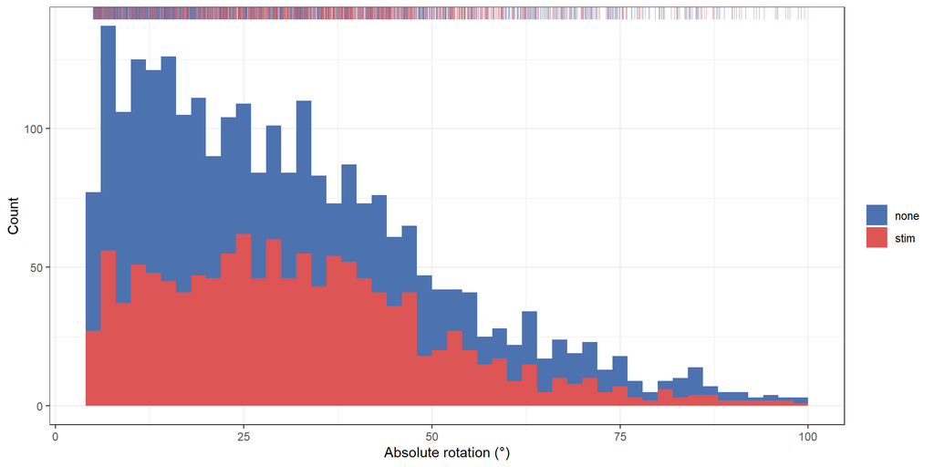

```r
ggplot(windows_sel, aes(x = abs_value, fill = real_stim)) +
        geom_histogram(breaks = seq(4, 100, 2), position = 'stack') +
        geom_rug(aes(colour = real_stim), sides = 't', alpha = 0.3, show.legend = FALSE) +
        scale_fill_manual(values = stim_colours) +
        scale_colour_manual(values = stim_colours) +
        labs(x = 'Absolute rotation (°)', y = 'Count', fill = '')
```

**Figure S5.1.** Absolute rotation in the 2 s after stimulus onset (red) and in matched no-stimulus windows (blue), stacked, 2° bins. Ticks on top: individual windows.

Rotations in both kinds of window spread over a wide range, because many spiders ignore the stimulus (overall response probability is around 0.3). To isolate the activity caused by the stimulus, we subtracted the no-stimulus histogram from the stimulus histogram, bin by bin.

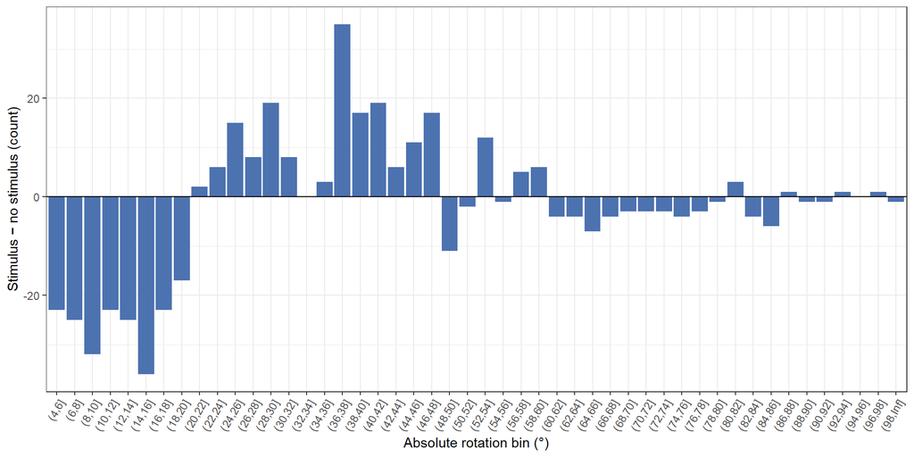

```r
breaks <- c(seq(4, 98, 2), Inf)
windows_sel$bin <- cut(windows_sel$abs_value, breaks = breaks)

counts <- dcast(windows_sel[, .N, by = .(bin, real_stim)], bin ~ real_stim, value.var = 'N', fill = 0)
counts$difference <- counts$stim - counts$none

ggplot(counts, aes(x = bin, y = difference)) +
        geom_col(fill = '#4C72B0') +
        geom_hline(yintercept = 0) +
        labs(x = 'Absolute rotation bin (°)', y = 'Stimulus − no stimulus (count)') +
        theme(axis.text.x = element_text(angle = 60, hjust = 1))
```

**Figure S5.2.** Count of stimulus windows minus count of no-stimulus windows, per 2° bin.

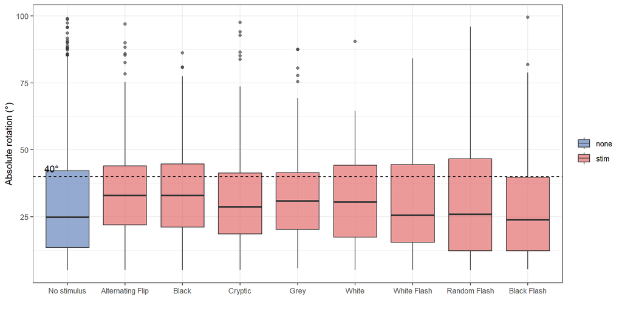

```r
ggplot(windows_sel, aes(x = stim, y = abs_value, fill = real_stim)) +
        geom_boxplot(alpha = 0.6) +
        geom_hline(yintercept = 40, linetype = 'dashed') +
        annotate('text', x = 0.6, y = 43, label = '40°', hjust = 0) +
        scale_fill_manual(values = stim_colours) +
        labs(x = '', y = 'Absolute rotation (°)', fill = '')
```

```r
windows_sel[, .(windows = .N, median = median(abs_value)), by = stim][order(stim)]
```

```
##                stim windows   median
##              <fctr>   <int>    <num>
## 1:      No stimulus    1326 24.84392
## 2: Alternating Flip     297 33.06051
## 3:            Black     255 32.98335
## 4:          Cryptic     245 28.78893
## 5:             Grey     128 30.94408
## 6:            White      93 30.56355
## 7:      White Flash      80 25.56702
## 8:     Random Flash      72 25.95610
## 9:      Black Flash      84 23.97099
```

**Figure S5.3.** Absolute rotation in the 2 s after onset, per stimulus type. Blue: no-stimulus windows. Dashed line: stimulus position (40°).

The median rotation is closest to 40° for the stimuli with the highest pivot probability (Black, Alternating Flip), and closest to the no-stimulus windows for the stimuli whose pivot probability is at baseline (the three flashes). The magnitude averaged over all presentations is thus a mixture of responding spiders, all turning about 40°, and non-responding spiders, generally turning less. It tracks the proportion of responders, which the binary measure estimates directly, and adds no independent information about how the stimuli were processed.

# 3 Pivot latency reflects scoring sensitivity

Our scoring procedure looks for the first pivot within 1.5 s of stimulus onset, and latency is the time from onset to the first deviation of the rotation trace from zero. Here we use only presentations in which a pivot was scored.

```r
scored <- pivots[turn == 1]

iqr_text <- function(x, digits) {
        q <- quantile(x, c(0.25, 0.5, 0.75), na.rm = TRUE)
        sprintf(paste0('%.', digits, 'f [%.', digits, 'f, %.', digits, 'f]'), q[2], q[1], q[3])
}

summarise_pivots <- function(all, scored) {
        out <- scored[, .(pivots = .N,
                          latency_s = iqr_text(turndelay, 2),
                          magnitude_deg = iqr_text(peakmagnitude, 0),
                          duration_s = iqr_text(peakduration, 2)), by = stim]
        out <- merge(all[, .(presentations = .N), by = stim], out, by = 'stim')
        out[, pivot_rate := round(pivots / presentations, 2)]
        out[order(-pivot_rate), .(stim, pivots, presentations, pivot_rate, latency_s, magnitude_deg, duration_s)]
}
```

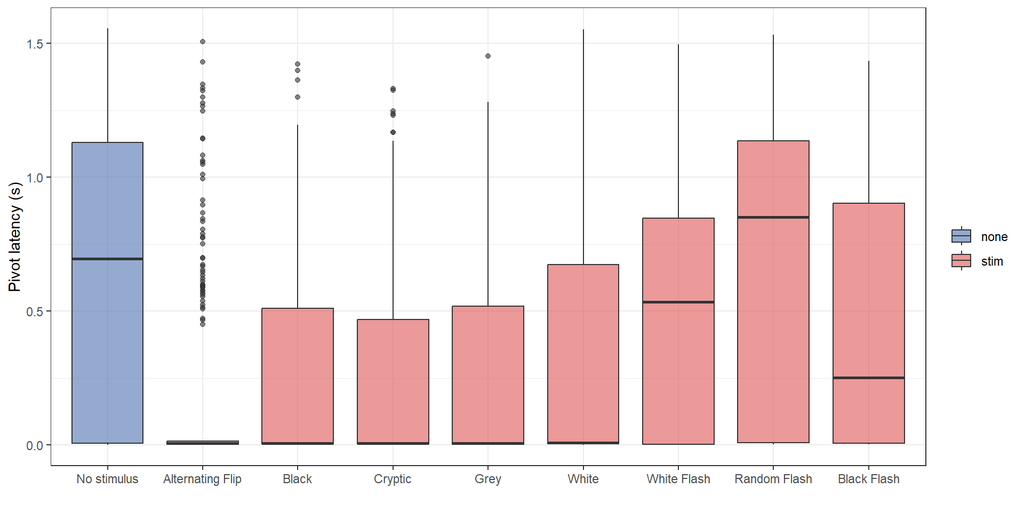

```r
ggplot(scored, aes(x = stim, y = turndelay, fill = real_stim)) +
        geom_boxplot(alpha = 0.6) +
        scale_fill_manual(values = stim_colours) +
        labs(x = '', y = 'Pivot latency (s)', fill = '')
```

**Figure S5.4.** Latency of scored pivots per stimulus type, Experiments 1 and 2. Blue: pivots scored during no-stimulus presentations.

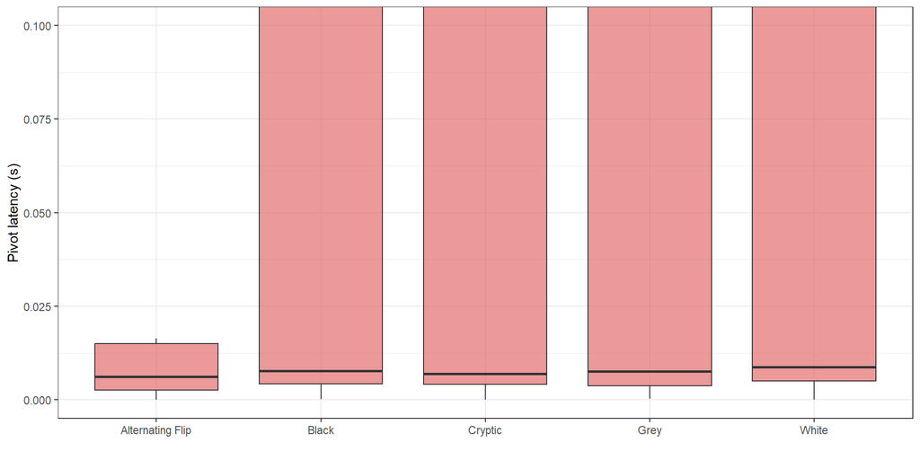

```r
responded <- c('Alternating Flip', 'Black', 'Cryptic', 'Grey', 'White')

ggplot(scored[stim %in% responded], aes(x = stim, y = turndelay)) +
        geom_boxplot(fill = stim_colours['stim'], alpha = 0.6, outlier.shape = NA) +
        coord_cartesian(ylim = c(0, 0.1)) +
        labs(x = '', y = 'Pivot latency (s)')
```

**Figure S5.5.** As Figure S5.4, restricted to the responded stimuli and zoomed on latencies below 0.1 s.

```r
kable(summarise_pivots(pivots, scored),
      col.names = c('Stimulus', 'Pivots', 'Presentations', 'Pivot rate',
                    'Latency (s)', 'Magnitude (°)', 'Duration (s)'),
      caption = 'Table S5.1. Scored pivots in Experiments 1 and 2, all spiders (no exclusion). Median [interquartile range].')
```

Table S5.1. Scored pivots in Experiments 1 and 2, all spiders (no exclusion). Median [interquartile range].

| Stimulus | Pivots | Presentations | Pivot rate | Latency (s) | Magnitude (°) | Duration (s) |
| --- | --- | --- | --- | --- | --- | --- |
| Alternating Flip | 249 | 598 | 0.42 | 0.01 [0.00, 0.02] | 43 [30, 56] | 0.63 [0.52, 0.72] |
| Black | 217 | 598 | 0.36 | 0.01 [0.00, 0.51] | 41 [27, 59] | 0.62 [0.46, 0.71] |
| Cryptic | 187 | 598 | 0.31 | 0.01 [0.00, 0.47] | 40 [27, 54] | 0.63 [0.51, 0.75] |
| Grey | 93 | 310 | 0.30 | 0.01 [0.00, 0.52] | 46 [30, 58] | 0.60 [0.46, 0.73] |
| White | 57 | 310 | 0.18 | 0.01 [0.01, 0.67] | 45 [27, 63] | 0.60 [0.45, 0.73] |
| White Flash | 37 | 288 | 0.13 | 0.53 [0.00, 0.85] | 35 [21, 59] | 0.47 [0.44, 0.71] |
| No stimulus | 398 | 3278 | 0.12 | 0.70 [0.01, 1.13] | 30 [19, 49] | 0.58 [0.46, 0.77] |
| Random Flash | 26 | 288 | 0.09 | 0.85 [0.01, 1.14] | 30 [19, 47] | 0.50 [0.44, 0.66] |
| Black Flash | 24 | 288 | 0.08 | 0.25 [0.01, 0.90] | 37 [28, 56] | 0.71 [0.49, 0.79] |

For the responded stimuli, the median latency is below 0.01 s. This is not an instantaneous reaction: the spider was often already moving at stimulus onset, and our procedure takes the first deviation from zero as the start of the pivot. In these cases the start of the pivot cannot be distinguished from the ongoing rotation. What is certain is that these are behaving animals.

The less a stimulus elicits responses, the longer the latency. This also follows from the scoring. A spider that is not responding, or is moving independently of the stimulus, has a growing chance of producing a “false” pivot the further the window extends past onset. If such pivots fall at random, their median latency should sit near the centre of the 1.5-s window, at about 0.75 s. This is what we observe for the no-stimulus control and the Random Flash, with the Black and White Flash in between. The distributions are very wide, so we do not interpret differences in latency further.

# 4 Black, White and Grey squares: pivots do not differ in magnitude, latency or duration

In Experiment 1, spiders pivoted more often to the Black square than to the White one, with the Grey square in between. We asked whether contrast could also affect how the spiders pivot, for example with smaller or slower responses to the lower-contrast Grey square.

On average, all three squares have the same contrast against the background. The background is a black-and-white checkerboard, so the Black and White squares have contrast 1 against half of it and 0 against the other half, while the Grey square has contrast 0.5 everywhere. Locally, the Grey square has half the contrast of the other two, although our monitor was not perfectly balanced. We included the Grey square precisely to check for contrast and resolution limits, expecting it to be the stimulus most likely to go undetected. This was not the case.

We again use only presentations in which a pivot was scored. This is necessary for latency, which exists only if a pivot is present. It also removes the mixture described above: by averaging responding trials only, we can see whether the continuous measures differ between stimuli once the proportion of responders is set aside.

```r
exp1        <- pivots[experiment == 'Exp1' & stim %in% c('No stimulus', 'Grey', 'White', 'Black')]
exp1_scored <- exp1[turn == 1]

exp1_long <- melt(exp1_scored,
                  id.vars = c('subjID', 'stim', 'real_stim'),
                  measure.vars = c('peakmagnitude', 'turndelay', 'peakduration'))
exp1_long$variable <- factor(exp1_long$variable,
                             levels = c('peakmagnitude', 'turndelay', 'peakduration'),
                             labels = c('Magnitude (°)', 'Latency (s)', 'Duration (s)'))
```

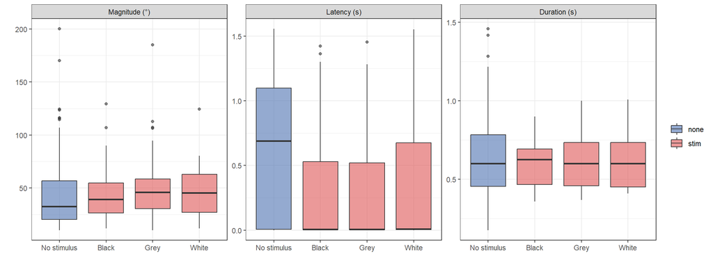

```r
ggplot(exp1_long, aes(x = stim, y = value, fill = real_stim)) +
        geom_boxplot(alpha = 0.6) +
        facet_wrap(~variable, scales = 'free_y') +
        scale_fill_manual(values = stim_colours) +
        labs(x = '', y = '', fill = '')
```

**Figure S5.6.** Magnitude, latency and duration of scored pivots in Experiment 1 for the Grey, White and Black squares. Blue: pivots scored during no-stimulus presentations. Duration is the time from movement onset to the return to rest.

```r
kable(summarise_pivots(exp1, exp1_scored),
      col.names = c('Stimulus', 'Pivots', 'Presentations', 'Pivot rate',
                    'Latency (s)', 'Magnitude (°)', 'Duration (s)'),
      caption = 'Table S5.2. Scored pivots in Experiment 1, all spiders. Median [interquartile range].')
```

Table S5.2. Scored pivots in Experiment 1, all spiders. Median [interquartile range].

| Stimulus | Pivots | Presentations | Pivot rate | Latency (s) | Magnitude (°) | Duration (s) |
| --- | --- | --- | --- | --- | --- | --- |
| Black | 95 | 310 | 0.31 | 0.01 [0.00, 0.53] | 39 [26, 55] | 0.62 [0.47, 0.69] |
| Grey | 93 | 310 | 0.30 | 0.01 [0.00, 0.52] | 46 [30, 58] | 0.60 [0.46, 0.73] |
| White | 57 | 310 | 0.18 | 0.01 [0.01, 0.67] | 45 [27, 63] | 0.60 [0.45, 0.73] |
| No stimulus | 199 | 1550 | 0.13 | 0.69 [0.01, 1.10] | 33 [20, 57] | 0.60 [0.45, 0.78] |

As a descriptive check, we compared the three squares with Kruskal-Wallis tests. Note that these tests ignore that pivots come from the same spiders.

```r
squares <- exp1_scored[stim != 'No stimulus']
squares$stim <- droplevels(squares$stim)

kruskal.test(peakmagnitude ~ stim, data = squares)
```

```
##
##  Kruskal-Wallis rank sum test
##
## data:  peakmagnitude by stim
## Kruskal-Wallis chi-squared = 2.036, df = 2, p-value = 0.3613
```

```r
kruskal.test(turndelay ~ stim, data = squares)
```

```
##
##  Kruskal-Wallis rank sum test
##
## data:  turndelay by stim
## Kruskal-Wallis chi-squared = 1.0519, df = 2, p-value = 0.591
```

```r
kruskal.test(peakduration ~ stim, data = squares)
```

```
##
##  Kruskal-Wallis rank sum test
##
## data:  peakduration by stim
## Kruskal-Wallis chi-squared = 0.064108, df = 2, p-value = 0.9685
```

The three squares do not differ in any measure. Median magnitude is about 40°, the stimulus position. Median latency is near 0 s, which again means the spiders were often already moving at onset. Median duration is about 0.6 s. These measures therefore cannot tell us more about how the squares are processed.

The difference in pivot rate between the Black and White squares remains to be explained. We suggest an ecological reason: jumping spiders often hunt dark flies moving over lighter backgrounds, and may be more prone to attend to stimuli of this kind. Such an effect would act on motivation, on top of detection, and is outside the scope of this study (see Discussion in the main text).